# RAIL Evaluation - Checking results against DC1 paper

The purpose of this notebook is to validate the reimplementation of the DC1 metrics, previously available on Github repository PZDC1paper, now refactored to be part of RAIL Evaluation module. The metrics here were implemented in object-oriented Python 3, following a superclass/subclass structure, and inheriting features from *qp*.

```python
from metrics import *
from utils import *
import os
%matplotlib inline
%reload_ext autoreload
%autoreload 2
```

### DC1 results

The DC1 results are stored in the class `DC1` (defined in `utils.py` ancillary file), which exists only to provide the reference values.

```python
dc1 = DC1()
```

```python
dc1.table
```

| Code | PIT out rate | KS | CvM | AD | CDE loss |
| --- | --- | --- | --- | --- | --- |
| ANNz2 | 0.0265 | 0.0200 | 52.2500 | 759.2000 | -6.8800 |
| BPZ | 0.0192 | 0.0388 | 280.7900 | 1557.5000 | -7.8200 |
| CMNN | 0.0034 | 0.0795 | 1011.1100 | 6307.5000 | -10.4300 |
| Delight | 0.0006 | 0.0876 | 1075.1700 | 6167.5000 | -8.3300 |
| EAZY | 0.0154 | 0.0723 | 1105.5800 | 4418.6000 | -7.0700 |
| FlexZBoost | 0.0202 | 0.0240 | 68.8300 | 478.8000 | -10.6000 |
| GPz | 0.0058 | 0.0241 | 66.8000 | 670.9000 | -9.9300 |
| LePhare | 0.0486 | 0.0663 | 473.0500 | 383.8000 | -1.6600 |
| METAPhoR | 0.0229 | 0.0438 | 298.5600 | 715.5000 | -6.2800 |
| SkyNet | 0.0001 | 0.0747 | 763.0000 | 4216.4000 | -7.8900 |
| TPZ | 0.0130 | 0.1138 | 1.1600 | 10565.7000 | -9.5500 |

To access individual metrics, one can call the metrics dictionary `dc1.results` using the codes and metrics names as keys.

```python
dc1.results['PIT out rate']['FlexZBoost']
```

```
0.0202
```

The list of codes and metrics available can be accessed by the properties `dc1.codes` and `dc1.metrics`.

```python
print(dc1.codes)
```

```
('ANNz2', 'BPZ', 'CMNN', 'Delight', 'EAZY', 'FlexZBoost', 'GPz', 'LePhare', 'METAPhoR', 'SkyNet', 'TPZ')
```

```python
print(dc1.metrics)
```

```
('PIT out rate', 'CDE loss', 'KS', 'CvM', 'AD')
```

## The data

In this notebook we use the same input dataset used in DC1 PZ paper ([Schmidt et al. 2020](https://arxiv.org/pdf/2001.03621.pdf)), copied from cori (/global/cfs/cdirs/lsst/groups/PZ/PhotoZDC1/photoz_results/TESTDC1FLEXZ).

```python
my_path = "/Users/julia/TESTDC1FLEXZ"

pdfs_file =  os.path.join(my_path, "Mar5Flexzgold_pz.out")
ztrue_file =  os.path.join(my_path, "Mar5Flexzgold_idszmag.out")
oldpitfile = os.path.join(my_path,"TESTPITVALS.out")
pdfs, zgrid, ztrue, photoz_mode = read_pz_output(pdfs_file, ztrue_file)
```

```
Validation file from DC1 paper (ascii format).
```

## Metrics

Metrics calculated based on the PITs computed via qp.Ensemble CDF method. The PIT values can be passed as optional input to speed up the metrics calculation. If no PIT array is provided, it is calculated on the fly.

```python
%%time
pit = PIT(pdfs, zgrid, ztrue)
pit.evaluate()
pits = pit.metric
```

```
CPU times: user 10min 2s, sys: 7.33 s, total: 10min 9s
Wall time: 24min 35s
```

```python
summary = Summary(pdfs, zgrid, ztrue)
summary.markdown_metrics_table(pits=pits, show_dc1="FlexZBoost")
```

| Metric | Value | DC1 reference value |
| --- | --- | --- |
| PIT out rate | 0.0192 | 0.0202 |
| KS | 0.0234 | 0.0240 |
| CvM | 71.1439 | 68.8300 |
| AD | 616.1850 | 478.8000 |
| KLD | 0.0348 | N/A |
| CDE loss | -10.62 | -10.60 |

#### PIT-QQ plot

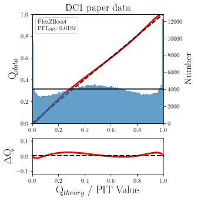

```python
pit_out_rate = PitOutRate(pdfs, zgrid, ztrue).evaluate(pits=pits)
pit.plot_pit_qq(title="DC1 paper data", code="FlexZBoost",
                pit_out_rate=pit_out_rate, savefig=False)
```

### "Debugging"

Following Sam's suggestion, I also computed the metrics reading the PIT values from the partial results of DC1 paper, instead of calculating them from scratch.

Reading DC1 PIT values (PITs computed in the past for the paper):

```python
pits_dc1 = np.loadtxt(oldpitfile, skiprows=1,usecols=(1))
```

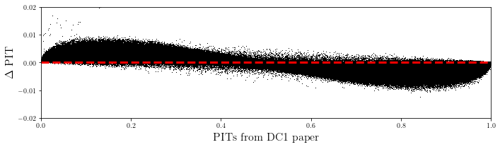

```python
plt.figure(figsize=[10,3])
plt.plot(pits_dc1, pits-pits_dc1, 'k,')
plt.plot([0,1], [0,0], 'r--', lw=3)
plt.xlim(0, 1)
plt.ylim(-0.02, 0.02)
plt.xlabel("PITs from DC1 paper")
plt.ylabel("$\Delta$ PIT")
plt.tight_layout()
```

The values are slightly different.

Recalculating the metrics:

```python
summary = Summary(pdfs, zgrid, ztrue)
summary.markdown_metrics_table(pits=pits_dc1, show_dc1="FlexZBoost")
```

```
5 PITs removed from the sample.
```

| Metric | Value | DC1 reference value |
| --- | --- | --- |
| PIT out rate | 0.0202 | 0.0202 |
| KS | 0.0240 | 0.0240 |
| CvM | 68.8262 | 68.8300 |
| AD | 663.4982 | 478.8000 |
| KLD | 0.0360 | N/A |
| CDE loss | -10.62 | -10.60 |

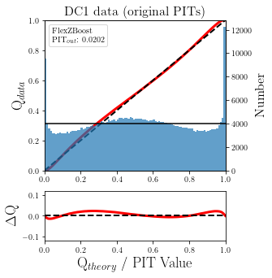

```python
pit_out_rate = PitOutRate(pdfs, zgrid, ztrue).evaluate(pits=pits_dc1)
pit.plot_pit_qq(title="DC1 data (original PITs)", code="FlexZBoost",
                pit_out_rate=pit_out_rate, savefig=False)
```

Using the original PIT values from the paper, all metrics match reasonably, except for the Anderson-Darling statistic.

#### Anderson-Darling

$$ \mathrm{AD}^2 \equiv N_{tot} \int_{-\infty}^{\infty} \frac{\big( \mathrm{CDF} \small[ \hat{f}, z \small] \ - \ \mathrm{CDF} \small[ \tilde{f}, z \small] \big)^{2}}{\mathrm{CDF} \small[ \hat{f}, z \small] \big( 1 \ - \ \mathrm{CDF} \small[ \tilde{f}, z \small] \big)}\mathrm{dCDF}(\tilde{f}, z) $$

The class AD uses `scipy.stats.anderson_ksamp` method to compute the Anderson-Darling statistic for the PIT values by comparing with a uniform distribution between 0 and 1. Up to the current version (1.6.2), `scipy.stats.anderson` (the 1-sample test) does not support uniform distributions as reference sample.

https://docs.scipy.org/doc/scipy/reference/generated/scipy.stats.anderson_ksamp.html

```python
ad_dc1 = dc1.results['AD']['FlexZBoost']
ad_dc1
```

```
478.8
```

```python
ad = AD(pdfs, zgrid, ztrue)
ad.evaluate(pits=pits_dc1)
ad.metric
```

```
5 PITs removed from the sample.
```

```
663.49815902956
```

By default, the AD is computed within the interval $0.0 \leq PIT \leq 1.0$.

5 objects have PIT values out of this interval (this is unexpected).

```python
print(pits_dc1[(pits_dc1<0)|(pits_dc1>1)])
```

```
[1.00008 1.00002 1.00041 1.00006 1.00002]
```

It is possible to remove extreme values of PIT, as done in the paper.

```python
ad.evaluate(pits=pits, ad_pit_min=0.0001, ad_pit_max=0.9999)
ad.metric
```

```
7683 PITs removed from the sample.
```

```
333.5984688987156
```

```python
ad.evaluate(pits=pits, ad_pit_min=0.001, ad_pit_max=0.999)
ad.metric
```

```
10588 PITs removed from the sample.
```

```
322.737851720298
```

```python
ad.evaluate(pits=pits, ad_pit_min=0.01, ad_pit_max=0.99)
ad.metric
```

```
21764 PITs removed from the sample.
```

```
386.4284099611739
```

```python
p_err = (abs(ad_dc1-ad.metric)/ad_dc1)*100. # percent error
print(f"Percent error: {p_err:.1f} %")
```

```
Percent error: 19.3 %
```

#### Point estimates metrics

These metrics are deprecated and might not be used in future analyses. They are included in this notebook for the sake of reproducing the results from the paper in its totality.

```python
utils.old_metrics_table(photoz_mode, ztrue, name="this test", show_dc1=True)
```

| Metric | this test | DC1 paper |
| --- | --- | --- |
| scatter | 0.0155 | 0.0154 |
| bias | -0.00027 | -0.00027 |
| outlier rate | 0.020 | 0.020 |

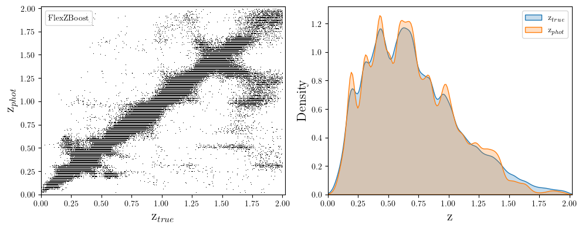

```python
utils.plot_old_valid(photoz_mode, ztrue, code="FlexZBoost")
```

## Conclusion

The metrics calculated using the new implementation are reasonably close to the expected values. Minor differences were observed due to the difference in the calculation of PIT values. In both cases, here and in the paper, the PITs were calculated using *qp* functions. The small diferences are attributed to minor changes in *qp* versions since when the paper was produced.

When using the original values of PIT, i.e., those calculated for the paper using the *qp* version availabe at the time, all metrics were reproduced, except for the AD test. This particular metric is quite sensitive to the range of PITs considered in the calculation. Using the same PIT interval as used in the paper (0.01,0.99), the result obtained using the new implementation diverges from the paper result by 19.3%.